# Clase 2 - Manipulación de bases de datos I

### group_by()

Esta función permite agrupar una operación para cada valor de una variable especificada. La función separa a la tabla según los valores de la variable indicada, y luego realiza las operaciones que se especifica continuación, de manera independiente para cada una de las “subtablas”.

Casi siempre van a ver (y usar) `group_by()` funcionando junto con `summarise()`. Es cuando trabajan en conjunto que revelan su verdadero poder.

En nuestro ejemplo, podemos calcular la cantidad de ocupados sobre habitantes totales de Argentina por fecha (se asumen 45 millones de habitantes).

```r
Datos %>%
  group_by(FECHA) %>%
  summarise("Ocupados por habitante" = OCUPADOS/45000000)
```

```
# A tibble: 9 × 2
# Groups:   FECHA [3]
  FECHA  `Ocupados por habitante`
  <chr>                     <dbl>
1 Ene-12                   0.136
2 Ene-12                   0.0565
3 Ene-12                   0.243
4 Feb-12                   0.136
5 Feb-12                   0.0577
6 Feb-12                   0.244
7 Mar-12                   0.136
8 Mar-12                   0.0578
9 Mar-12                   0.244
```

## Joins

Otra implementación muy importante del paquete dplyr son las funciones para unir tablas (joins)

### left_join()

Veamos un ejemplo de la función left_join (una de las más utilizadas en la práctica). Utilicemos una base similar a la anterior, pero en este caso serán datos del [Indice de Salarios](https://www.indec.gob.ar/indec/web/Nivel4-Tema-4-31-61).

```r
INDICE  <- c(100,   100,   100,
             101.8, 101.2, 100.73,
             102.9, 102.4, 103.2)
FECHA  <-  c("Oct-16", "Oct-16", "Oct-16",
             "Nov-16", "Nov-16", "Nov-16",
             "Dic-16", "Dic-16", "Dic-16")
GRUPO  <-  c("Privado_Registrado","Público","Privado_No_Registrado",
             "Privado_Registrado","Público","Privado_No_Registrado",
             "Privado_Registrado","Público","Privado_No_Registrado")
IS <- data.frame(INDICE, FECHA, GRUPO)
```

Para ello, crearemos en forma simultanea previamente un dataframe que contenga un Ponderador para cada uno de los Grupos del Dataframe IS.

```r
Ponderadores <- data.frame(GRUPO = c("Privado_Registrado","Público","Privado_No_Registrado"),
                            PONDERADOR = c(50.16,29.91,19.93))
IS_join <- IS %>%
  left_join(.,Ponderadores, by = "GRUPO")
IS_join
```

```
  INDICE  FECHA                 GRUPO PONDERADOR
1 100.00 Oct-16    Privado_Registrado      50.16
2 100.00 Oct-16               Público      29.91
3 100.00 Oct-16 Privado_No_Registrado      19.93
4 101.80 Nov-16    Privado_Registrado      50.16
5 101.20 Nov-16               Público      29.91
6 100.73 Nov-16 Privado_No_Registrado      19.93
7 102.90 Dic-16    Privado_Registrado      50.16
8 102.40 Dic-16               Público      29.91
9 103.20 Dic-16 Privado_No_Registrado      19.93
```

Aprovecharemos el ejemplo para introducir la función weigthed.mean, y así calcular un Indice Ponderado.

```r
IS_Indice_Gral <- IS_join %>%
  group_by(FECHA) %>%
  summarise(Indice_Gral = weighted.mean(INDICE,w = PONDERADOR))
IS_Indice_Gral
```

```
# A tibble: 3 × 2
  FECHA  Indice_Gral
  <chr>        <dbl>
1 Dic-16        103.
2 Nov-16        101.
3 Oct-16        100
```

## Tidyr

El paquete tidyr esta pensado para facilitar el emprolijamiento de los datos. Veremos las funciones pivot_longer y pivot_wider que nos permitirán pivotear la base según como queramos ordenar los datos para trabajarlos posteriormente o bien para presentarlos como tabla de resultados.

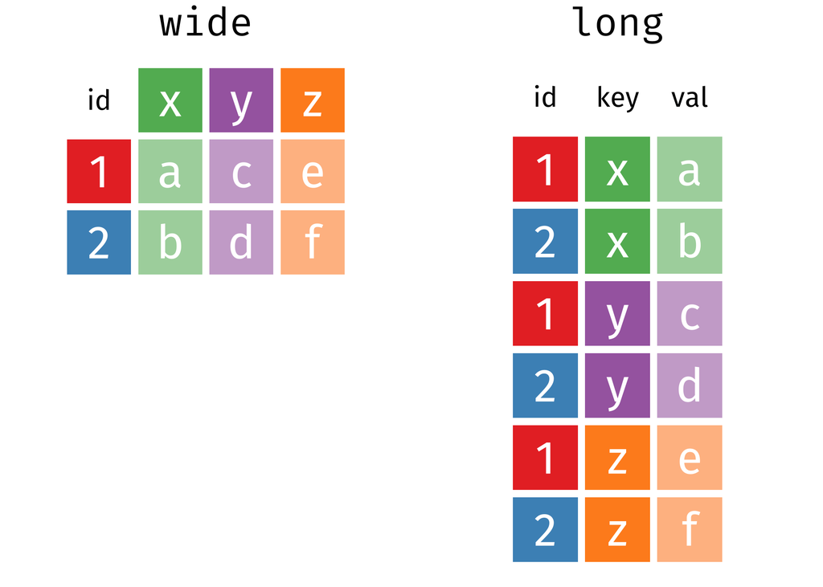

### pivot_longer()

Nos permite pivotear los datos en columnas hacia una única variable. El *“longer”* refiere a que ahora nuestro dataframe va a tener más filas (y menos columnas). Veamos un ejemplo con la base de datos del paquete gapminder y aprovechemos la función `sample_n()`:

```r
library(gapminder)

gapminder %>% sample_n(size = 6)
```

| country | continent | year | lifeExp | pop | gdpPercap |
| --- | --- | --- | --- | --- | --- |
| Colombia | Americas | 1967 | 59.963 | 19764027 | 2678.730 |
| Serbia | Europe | 1962 | 64.531 | 7616060 | 6289.629 |
| Nigeria | Africa | 1987 | 46.886 | 81551520 | 1385.030 |
| Sudan | Africa | 1982 | 50.338 | 20367053 | 1895.544 |
| Turkey | Europe | 1982 | 61.036 | 47328791 | 4241.356 |
| Egypt | Africa | 2007 | 71.338 | 80264543 | 5581.181 |

```r
gapminder_long <- gapminder %>%
  pivot_longer(
    cols = c(lifeExp, pop, gdpPercap),
    names_to = "variable",  # Nombre de la columna para los nombres de las variables
    values_to = "valor"     # Nombre de la columna para los valores
  )

# Visualizamos el resultado
head(gapminder_long, 6)
```

[output not shown]

```r
# Los mismos datos de antes pero en formato ancho
datos_ancho <- data.frame(
    SECTOR = c("Privado_Registrado", "Público", "Total"),
    `Ene-12` = c(6105953, 2543717, 10931300),
    `Feb-12` = c(6103382, 2598154, 10982740),
    `Mar-12` = c(6112372, 2602057, 10992215),
    check.names = FALSE # para que no cargue las fechas como Ene.12, etc.
)
```

| SECTOR | Ene-12 | Feb-12 | Mar-12 |
| --- | --- | --- | --- |
| Privado_Registrado | 6105953 | 6103382 | 6112372 |
| Público | 2543717 | 2598154 | 2602057 |
| Total | 10931300 | 10982740 | 10992215 |

```r
datos_largo <- datos_ancho %>%
  pivot_longer(
    cols = -SECTOR,           # Todas las columnas excepto SECTOR
    names_to = "FECHA",       # Nombre de la nueva columna para las fechas
    values_to = "OCUPADOS"    # Nombre de la nueva columna para los valores
  )
```

| SECTOR | FECHA | OCUPADOS |
| --- | --- | --- |
| Privado_Registrado | Ene-12 | 6105953 |
| Privado_Registrado | Feb-12 | 6103382 |
| Privado_Registrado | Mar-12 | 6112372 |
| Público | Ene-12 | 2543717 |
| Público | Feb-12 | 2598154 |
| Público | Mar-12 | 2602057 |
| Total | Ene-12 | 10931300 |
| Total | Feb-12 | 10982740 |
| Total | Mar-12 | 10992215 |

## Medidas de resumen de las variables en una base de datos

Las funciones previamente presentadas responder a un conjunto de herramientas que tienen por finalidad operar sobre la base de datos que un usuario desea analizar. A continuación, se presentarán funciones cuya finalidad es analizar datos prexistentes en la base misma, sin el objetivo inmediato de realizar transformaciones sobre dichos datos.

### summary()

Resume la información de cada una de las variables de la base de datos, mostrando distintos momentos de la distribución para variables numéricas, y un conteo de casos para variables del tipo factor o character. No confundan `summary()`, sustantivo, con `summarise()`, verbo.

```r
summary(Datos)
```

```
    OCUPADOS           FECHA              SECTOR             Promedio
 Min.   : 2543717   Length:9           Length:9           Min.   :6552432
 1st Qu.: 2602057   Class :character   Class :character   1st Qu.:6552432
 Median : 6105953   Mode  :character   Mode  :character   Median :6552432
 Mean   : 6552432                                         Mean   :6552432
 3rd Qu.:10931300                                         3rd Qu.:6552432
 Max.   :10992215                                         Max.   :6552432

  caso_cuando
 Min.   : 7631151
 1st Qu.: 7797389
 Median :10006468
 Mean   : 9979200
 3rd Qu.:12210620
 Max.   :12224744
 NA's   :3
```

### unique()

Permite ver los valores únicos que toma cierta variable/columna en mi base de datos.

```r
unique(Datos$SECTOR)
```

```
[1] "Privado_Registrado" "Público"            "Total"
```

### sample_n()

Esta función está dentro del paquete tidyverse. Nos permite seleccionar de manera muy simple una muestra al azar de n casos de nuestra base de datos. Puede ser útil para una primera mirada de la base que trascienda a los primeros casos, o bien para procedimienos de muestreo aleatorio.

```r
sample_n(tbl = Datos,size = 9)
```

```
  OCUPADOS  FECHA             SECTOR Promedio caso_cuando
1  6112372 Mar-12 Privado_Registrado  6552432    12224744
2 10931300 Ene-12              Total  6552432          NA
3  6103382 Feb-12 Privado_Registrado  6552432    12206764
4  2543717 Ene-12            Público  6552432     7631151
5 10982740 Feb-12              Total  6552432          NA
6  6105953 Ene-12 Privado_Registrado  6552432    12211906
7  2602057 Mar-12            Público  6552432     7806171
8 10992215 Mar-12              Total  6552432          NA
9  2598154 Feb-12            Público  6552432     7794462
```

### table()

Esta función puede utilizarse para hacer tabulados univariados o bivariados en variables discretas.

```r
table(Datos$SECTOR)
```

```
Privado_Registrado            Público              Total
                 3                  3                  3
```

## References

R Core Team. (2024). *R: A Language and Environment for Statistical Computing*. R Foundation for Statistical Computing, Vienna, Austria. Recuperado de https://www.R-project.org/

CEPED. (2022). Ceped.data. Portal de difusión de datos del Centro de Estudios sobre Población, Empleo y Desarrollo (CEPED-UBA), Universidad de Buenos Aires, Buenos Aires. Recuperado de https://ceped-data.shinyapps.io/ceped-data/

Tiscornia, P., Weksler, G., Kozlowski D. y Shokida N. (2019). Introducción a R para Ciencias Sociales. Aplicación practica en la EPH. Recuperado de https://diegokoz.github.io/R_EPH_bookdown/index.html

[Diplomatura Problemas Actuales de la Economía, el Empleo y el Comercio](https://ceped-fce-uba.github.io/diplomatura_economia/)

*diplo.problemas.economia@gmail.com*